# Analyse des Jeux Olympiques

THX1138

2025-04-23

## Introduction

Nous sommes des étudiants de l’Université de Technologie de Troyes et réalisons ce projet dans le cadre de l’UE **IF36** (intitulée : Visualiser des données). Ce projet nous permet de découvrir et d’acquérir des compétences en **data visualisation**, ainsi que de consolider nos connaissances en **R** à travers l’analyse de données issues des Jeux Olympiques.

L’objectif de notre étude est d’analyser les données des Jeux Olympiques entre **1896 et 2020** afin d’identifier des tendances et répondre à différentes questions. Nous nous interrogerons notamment sur l’impact du pays hôte sur les performances des athlètes nationaux, la répartition géographique des médaillés ou encore la domination de certains pays dans des disciplines spécifiques.

### Données

Pour notre analyse, nous avons sélectionné trois datasets relatifs aux Jeux Olympiques. Ces derniers sont disponibles sur Kaggle :

#### 1. [**Olympics 124 years Dataset(till 2020)**](https://www.kaggle.com/datasets/nitishsharma01/olympics-124-years-datasettill-2020)

##### Nombre d’observations et de variables

Le dataset contient **environ 238 000 observations** et **13 variables**. Chaque ligne représente un athlète ayant participé à une épreuve spécifique lors des Jeux Olympiques d’été entre **1896 et 2020**.

##### Description des variables

- **Identifiants uniques** :
  - `ID` : Identifiant unique de l’entrée associant un athlète à une épreuve lors d’une session des jeux.
  - `Name` : Nom de l’athlète
- **Informations démographiques** :
  - `Sex` : Sexe de l’athlète (`M` / `F`)
  - `Age` : Âge de l’athlète (valeurs entre **10 et 97 ans**, avec une moyenne de **25,7 ans**)
- **Données liées au pays** :
  - `Team` : Nom du pays représenté
  - `NOC` : Code du Comité National Olympique
- **Données sur l’édition des JO** :
  - `Games` : Année et saison des JO (`ex: 2020 Summer`)
  - `Year` : Année des JO (de **1896 à 2020**)
  - `Season` : Saison (`Summer` ou `Winter`)
  - `City` : Ville hôte
- **Données sportives et résultats** :
  - `Sport` : Discipline sportive
  - `Event` : Épreuve spécifique
  - `Medal` : Type de médaille remportée (`Gold`, `Silver`, `Bronze`, ou `None`, dans le dernier cas le champ est simplement vide)

On mentionnera également le fichier regions.csv reprenant le `NOC` et l’associant à la région de ce comité ainsi qu’à une note éventuelle le concernant. Celui-ci nous permettra éventuellement d’obtenir des informations complémentaires rendant certains résultats plus clairs.

##### Origine et pertinence du dataset

Ce dataset provient de **Kaggle** et a été sélectionné pour son **exhaustivité et sa richesse en informations**, couvrant plus d’un siècle de compétitions olympiques. Il permet d’analyser : - **L’évolution des Jeux Olympiques**, du nombre d’athlètes et de pays participants - **Les performances des nations et des athlètes** - **Les tendances historiques** influencées par les guerres, boycotts et changements de règlements - **Les disparités de genre dans le sport olympique**

Il s’intègre parfaitement dans notre projet sur la **visualisation et l’analyse des tendances olympiques**.

##### Format et structure des données

Le dataset est en **format CSV**, structuré de manière tabulaire et exploitable avec des outils de **data science** comme **R (tidyverse, ggplot2, dplyr)**.

- **Types de variables** :
  - **Catégoriques** : `Sex`, `Team`, `NOC`, `Games`, `Season`, `City`, `Sport`, `Event`, `Medal`
  - **Numériques** : `Age`, `Year`
  - **Identifiants uniques** : `ID`
- **Données manquantes** :
  - `Age` : 4 % de valeurs manquantes (≈ 9 189 observations)
  - `Medal` : Contient de nombreuses valeurs `None`, représentant les athlètes n’ayant pas remporté de médaille.

**Catégories et sous-groupes dans les données**  
Le dataset peut être divisé en plusieurs groupes d’analyse :  
1. **Par saison** : Jeux d’été & jeux d’hiver 2. **Par pays** : Comparaison des performances via `Team` et `NOC` 3. **Par discipline** : Étude des sports les plus compétitifs et leur évolution 4. **Par médaille** : Analyse des athlètes et pays ayant remporté le plus de médailles 5. **Par période historique** : Impact des guerres, boycotts et modifications des règles

Ce dataset offre une **opportunité unique d’explorer les tendances des JO**, aussi bien sur le plan **démographique, sportif que géopolitique**.

#### 2. [**Summer Olympic Medals 1896 - 2020**](https://www.kaggle.com/datasets/ramontanoeiro/summer-olympic-medals-1986-2020)

##### Nombre d’observations et de variables

Le dataset contient **1344 observations** et **8 variables**. Chaque ligne représente le nombre de médailles remportées par un pays lors d’une édition des Jeux Olympiques d’été entre **1896 et 2020**.

##### Description des variables

- **Informations sur l’édition des JO** :
  - `Year` : Année des Jeux
  - `Host_country` : Pays hôte des Jeux
  - `Host_city` : Ville hôte des Jeux
- **Données sur les pays participants** :
  - `Country_Name` : Nom du pays participant
  - `Country_Code` : Code du pays (ex: USA, FRA, GER)
- **Données sur les médailles remportées par le pays participant** :
  - `Gold` : Nombre de médailles d’or remportées
  - `Silver` : Nombre de médailles d’argent remportées
  - `Bronze` : Nombre de médailles de bronze remportées

##### Origine et pertinence du dataset

Ce dataset provient de **Kaggle** et se concentre sur la **performance des pays aux Jeux Olympiques d’été** à travers le nombre de médailles obtenues. Il est pertinent pour analyser :  
- **L’évolution des performances des pays** sur plus d’un siècle de compétitions - **Les tendances en matière de domination olympique** et l’impact des pays hôtes - **L’influence des guerres, boycotts et autres événements historiques** sur la répartition des médailles - **Les variations de performances des nations émergentes et puissances sportives historiques**

Ce dataset s’intègre parfaitement dans un projet de **visualisation et d’analyse des performances olympiques par pays**.

##### Format et structure des données

Le dataset est en **format CSV**, organisé sous une structure tabulaire exploitable avec des outils de **data science** comme **R (tidyverse, ggplot2, dplyr)**.

- **Types de variables** :
  - **Catégoriques** : `Host_country`, `Host_city`, `Country_Name`, `Country_Code`
  - **Numériques** : `Year`, `Gold`, `Silver`, `Bronze`
- **Données manquantes** :
  - `Country_Code` : 6 % de valeurs manquantes (86 observations)

**Catégories et sous-groupes dans les données**  
Ce dataset peut être segmenté selon plusieurs axes d’analyse :  
1. **Par édition des JO** : Comparaison des performances des pays sur chaque édition 2. **Par pays** : Évolution des performances d’un pays à travers les différentes années 3. **Par type de médaille** : Répartition des médailles d’or, d’argent et de bronze 4. **Par pays hôte** : Étude de l’impact du pays hôte sur la répartition des médailles 5. **Par période historique** : Influence des événements géopolitiques sur les résultats

Ce dataset constitue une **ressource précieuse pour étudier les performances olympiques des nations** et comprendre **l’évolution des tendances sportives au fil du temps**.

#### 3. [**Olympics Athlete Events Analysis**](https://www.kaggle.com/datasets/samruddhim/olympics-althlete-events-analysis)

##### Nombre d’observations et de variables

Le dataset contient **environ 271 000 observations** et **15 variables**. Chaque ligne représente un athlète ayant participé à une épreuve spécifique lors des Jeux Olympiques d’été et d’hiver, depuis **1896**.

##### Description des variables

- **Identifiants uniques** :
  - `ID` : Identifiant unique de l’athlète
  - `Name` : Nom de l’athlète
- **Informations démographiques** :
  - `Sex` : Sexe de l’athlète (`M` / `F`)
  - `Age` : Âge de l’athlète (valeurs entre **10 et 97 ans**, avec une moyenne de **25,7 ans**)
- **Données liées au pays** :
  - `Team` : Nom du pays représenté
  - `NOC` : Code du Comité National Olympique
- **Données sur l’édition des JO** :
  - `Games` : Année et saison des JO (`ex: 2020 Summer`)
  - `Year` : Année des JO (de **1896 à 2020**)
  - `Season` : Saison (`Summer` / `Winter`)
  - `City` : Ville hôte
- **Données sportives et résultats** :
  - `Sport` : Discipline sportive
  - `Event` : Épreuve spécifique
  - `Medal` : Type de médaille remportée (`Gold`, `Silver`, `Bronze`, ou `None`)

##### Origine et pertinence du dataset

Ce dataset provient de **Kaggle** et a été sélectionné pour son **exhaustivité et sa richesse en informations**, couvrant plus d’un siècle de compétitions olympiques. Il permet d’analyser : - **L’évolution des Jeux Olympiques**, du nombre d’athlètes et de pays participants - **Les performances des nations et des athlètes** - **Les tendances historiques** influencées par les guerres, boycotts et changements de règlements - **Les disparités de genre dans le sport olympique**

Ce dataset est particulièrement pertinent pour les projets d’**analyse de données sportives** et peut être utilisé pour la **visualisation** et l’**analyse des tendances olympiques**.

##### Format et structure des données

Le dataset est en **format CSV**, structuré de manière tabulaire et exploitable avec des outils de **data science** comme **R (tidyverse, ggplot2, dplyr)**.

- **Types de variables** :
  - **Catégoriques** : `Sex`, `Team`, `NOC`, `Games`, `Season`, `City`, `Sport`, `Event`, `Medal`
  - **Numériques** : `Age`, `Year`
  - **Identifiants uniques** : `ID`
- **Données manquantes** :
  - `Age` : 4 % de valeurs manquantes (≈ 9 189 observations)
  - `Medal` : Contient de nombreuses valeurs `None`, représentant les athlètes n’ayant pas remporté de médaille.

**Catégories et sous-groupes dans les données**  
Le dataset peut être divisé en plusieurs groupes d’analyse : 1. **Par saison** : Jeux d’été (`Summer`) et d’hiver (`Winter`) 2. **Par pays** : Comparaison des performances via `Team` et `NOC` 3. **Par discipline** : Étude des sports les plus compétitifs et leur évolution 4. **Par médaille** : Analyse des athlètes et pays ayant remporté le plus de médailles 5. **Par période historique** : Impact des guerres, boycotts et modifications des règles

Ce dataset offre une **opportunité unique d’explorer les tendances des JO**, aussi bien sur le plan **démographique, sportif que géopolitique**.

### Plan d’analyse

Voici les questions que nous souhaitons explorer à travers ces données :

- **Évolution de la participation** : Comment le nombre d’athlètes et de pays participants a-t-il évolué au fil des Jeux Olympiques ?
- **Analyse morphologique** : Quelle est la répartition par taille et poids des athlètes au fil du temps et selon les disciplines ?
- **Impact du pays hôte** : Un pays organisateur a-t-il un avantage en termes de performances et de médailles remportées lorsqu’il accueille les Jeux ? Comment évolue la performance des athlètes locaux par rapport aux éditions précédentes et suivantes ? Y’a il un impact géographique sur les performances des athlètes (exemple :altitude)
- **Corrélations possibles** : Existe-t-il une corrélation entre l’âge des athlètes et leur performance dans certaines disciplines ?
- **Analyse des villes hôtes** : Y a-t-il une tendance géographique dans le choix des villes hôtes au fil des années ?
- **Performance individuelle** : Quels athlètes ont remporté le plus de médailles au cours de leur carrière ?
- **Disparités de genre** : Comment la participation et la performance des femmes aux Jeux Olympiques ont-elles évolué depuis leur introduction ?

Pour répondre à ces questions, nous comparerons des variables telles que le nombre d’athlètes, le nombre de pays participants, le nombre de médailles remportées, l’âge des athlètes, etc. Nous devrons également être attentifs aux éventuelles incohérences ou valeurs manquantes dans les données, ainsi qu’aux changements de catégories ou de disciplines au fil du temps, qui pourraient compliquer certaines analyses. La comparabilité entre différentes époques constitue également un enjeu majeur, car les règlements et les disciplines olympiques ont évolué au fil du temps, impactant les performances et les classements. De plus, des événements historiques tels que les boycotts ou les guerres ont parfois limité la participation de certains pays, ce qui pourrait biaiser certaines analyses. Il sera donc essentiel de prendre en compte ces facteurs pour garantir la pertinence et la fiabilité des conclusions.

## 1. L’effet pays hôte

Dans cette analyse exploratoire, nous cherchons à comprendre si le fait d’accueillir les Jeux Olympiques d’été procure un avantage aux pays hôtes.

Nous supposons dès le départ que les pays hôtes des Jeux Olympiques d’été remporteront un plus grand nombre de médailles, en particulier des médailles d’or. Cela pourrait être dû à plusieurs facteurs : tout d’abord, le soutien massif du public local peut offrir un avantage psychologique aux athlètes, les poussant à surperformer, notamment lors des épreuves les plus disputées. Ensuite, la familiarité avec l’environnement et l’absence de problèmes d’acclimatation logistique peuvent offrir aux athlètes un confort supplémentaire qui se traduit par de meilleures performances. Enfin, bien que cela soit plus controversé, l’effet de l’arbitrage pourrait être légèrement influencé par la pression exercée par la foule et les attentes nationales, particulièrement dans les finales où les résultats sont souvent plus serrés.

### Question 1 : Correlation entre pays hotes et nombre de médailles

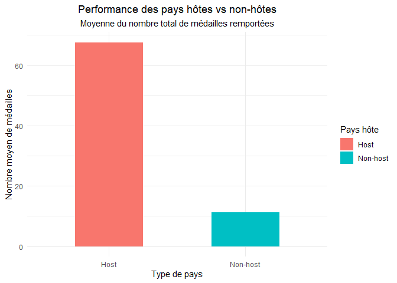

### Interprétation

Le graphique montre que les pays hôtes remportent en moyenne un nombre bien plus élevé de médailles que les pays non hôtes lors d’une édition donnée. Cela confirme notre hypothèse de départ : être pays organisateur semble conférer un avantage compétitif évident. Toutefois, une question importante se pose : cet avantage est-il également présent pour toutes les médailles (or, argent, bronze) ou est-il principalement concentré sur les médailles d’or ? Comme les finales pour les médailles d’or attirent souvent une attention médiatique et émotionnelle particulière, il est plausible que l’effet pays hôte soit particulièrement visible à ce niveau.

### Question 2 : Distribution par type de médaille

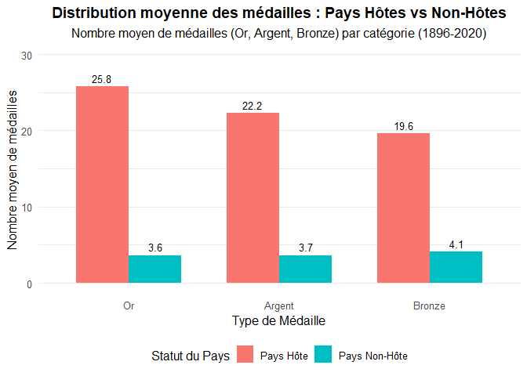

### Interprétation

L’avantage du pays hôte est visible pour tous les types de médailles, avec un effet plus prononcé pour les médailles d’or. Les pays hôtes remportent en moyenne 4 médailles d’or de plus que d’argent ou de bronze, tandis que cette distribution est plus équilibrée pour les pays non-hôtes. Cette légère surreprésentation des médailles d’or confirme que l’avantage du pays hôte est déterminant dans les moments décisifs des compétitions

### Question 3: Évolution des médailles entre 3 éditions avant et l’année hôte

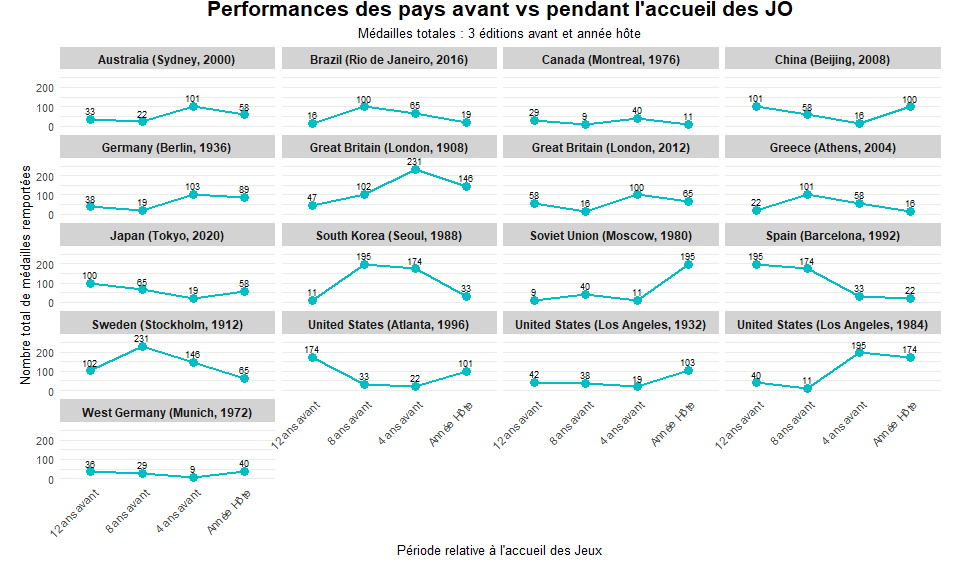

### Interpretation

Nous avions initialement émis l’hypothèse que les pays hôtes remporteraient davantage de médailles, notamment d’or, grâce au soutien local et à la familiarité. Les observations générales confirment bien que les pays hôtes obtiennent en moyenne un nombre de médailles significativement plus élevé.

Cependant, une analyse plus fine de l’“Évolution des médailles totales des pays hôtes : Tendances avant et pendant l’accueil des JO” nuance cette moyenne. En examinant les trajectoires individuelles (12, 8 et 4 ans avant, puis l’année hôte), nous constatons que l’idée d’un “boost” systématique et toujours prononcé est plus complexe.

Cette observation nous conduit à une question essentielle pour la suite : si l’effet “boost” immédiat est plus nuancé et souvent lié à une force sportive préexistante, quelle est l’influence de l’accueil des Jeux sur le long terme ? Nous allons maintenant explorer si les investissements et l’enthousiasme générés entraînent une performance accrue durablement, et si cela concerne particulièrement les pays qui n’étaient pas des “géants” des médailles avant d’être hôtes, cherchant ainsi des seuils ou des schémas de croissance post-olympique.

### Question 4: Influence après avoir été hôte (comparaison des moyennes avant et après): impacte sur le long terme

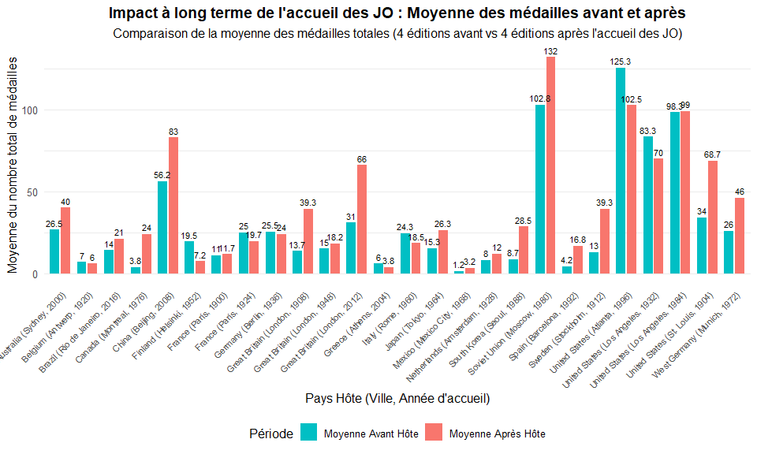

### Interpretation

Le graphique “Impact à long terme de l’accueil des JO : Moyenne des médailles avant et après” offre une perspective cruciale sur la durabilité de “l’effet pays hôte”. Il compare la moyenne du nombre total de médailles remportées par un pays sur les quatre éditions olympiques précédant son statut d’hôte (moyenne “Avant Hôte”) et sur les quatre éditions suivant cet événement (moyenne “Après Hôte”).

En examinant ce graphique, nous observons un impact positif à long terme sur le nombre de médailles pour de nombreuses nations après avoir été hôtes. L’investissement dans les infrastructures, la modernisation des équipements et l’élan national généré par l’organisation des Jeux semblent, dans l’ensemble, contribuer à maintenir, voire à améliorer, le niveau sportif des pays sur la durée.

Les recherches sur l’héritage olympique confirment que l’impact à long terme est complexe et dépend moins de l’événement lui-même que de la capacité du pays à transformer cet élan en une stratégie sportive nationale durable. Cela inclut la qualité des structures préexistantes, l’investissement stratégique post-Jeux et des politiques sportives cohérentes.

## 2. Existe-t-il une corrélation entre l’âge des athlètes et leur performance dans certaines disciplines

Nous cherchons à comprendre si l’âge des athlètes est un facteur clé de leur performance, en particulier à travers l’obtention de médailles, et si cette influence varie selon les disciplines sportives.

Nous partons de l’hypothèse que l’âge optimal de performance pourrait différer selon les sports :  
- Dans des disciplines nécessitant puissance, vitesse et explosivité (ex: gymnastique, natation), les athlètes seraient plus jeunes.  
- Tandis que dans des disciplines nécessitant technique, expérience ou endurance mentale (ex: tir, équitation), les athlètes performants seraient plus âgés.

### Question 1 : Âge moyen par sport

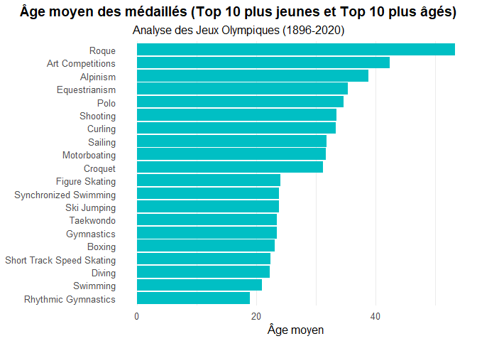

(La version interactive de ce graphique est présente sur shiny app afin de visualiser la moyenne pour différents sports)

### Interprétation

Le graphique montre des différences marquées d’âge moyen selon les disciplines :

- Sports d’explosivité (ex: gymnastique, natation, plongeon) : Les athlètes ayant remporté des médailles sont très jeunes, avec un âge moyen souvent inférieur à 25 ans. Cela confirme l’idée que jeunesse et qualités physiques maximales (force, agilité, récupération rapide) sont déterminantes.
- Sports d’adresse et d’expérience (ex: tir, équitation, roque) : Les médaillés sont sensiblement plus âgés, avec un âge moyen dépassant 30 ans dans certaines disciplines. Ces sports nécessitent davantage de maîtrise technique, de calme, d’expérience et moins de dépendance à la performance physique brute.

Cela soulève cependant une autre question : Est-ce que la couleur de la médaille remportée dépend de l’âge des athlètes ?

On pourrait s’attendre à ce que les trois athlètes montant sur le podium (médailles d’or, d’argent et de bronze) soient globalement du même âge.

### Question 2 : Distribution âge par type de médaille

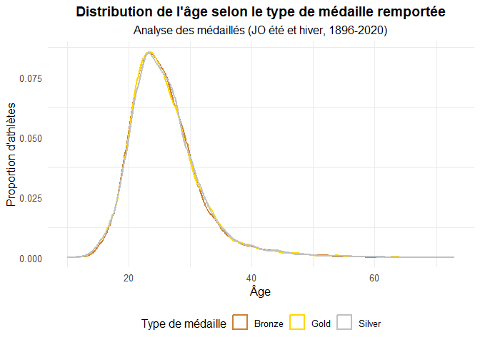

### Interprétation

Le graphique présente la distribution de l’âge des athlètes médaillés aux Jeux Olympiques (de 1896 à 2020) selon le type de médaille remportée (bronze, argent, or).

On observe que :

- La majorité des athlètes médaillés ont entre 20 et 30 ans, avec un pic autour de 23 ans.
- La forme de la distribution est très similaire pour les trois types de médailles : bronze, argent et or.

Le graphique suggère donc que, dans une même épreuve, les trois athlètes présents sur le podium (médailles d’or, d’argent et de bronze) ont en moyenne un âge similaire.

## 3. Disparités de genre

Nous cherchons ici à détecter et observer les disparités de genre au fil de l’histoire des Jeux. On cherchera notamment à déterminer les facteurs impactant ces disparités et leurs évolutions.

### Question 1 : Évolution des participations par sexe

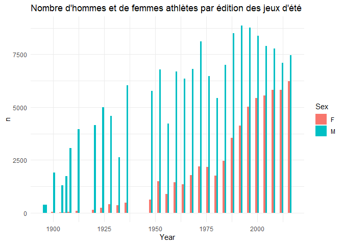

### Interprétation

Le graphique dépeint l’évolution de la participation des hommes et desfemmes aux jeux olympiques d’été. Deux éléments principaux en ressortent :

1. La part de femmes et systématiquement minoritaire de façon très nette.
2. Le nombre d’athlètes féminines est en augmentation quasi constante, notamment sur les dernières années et ce même quand les hommes deviennent moins nombreux. En conséquent l’écart semble se réduire de façon quasiment constante.

Il semble également y avoir eu une grande accélération dans cette réduction des disparités entre les années 1980 et 2000. On peut aisément attribuer cette évolution à l’éveil des consciences et aux mouvements sociaux qui ont eu lieu à l’époque.

### Question 2 : Évolution des performances par sexe

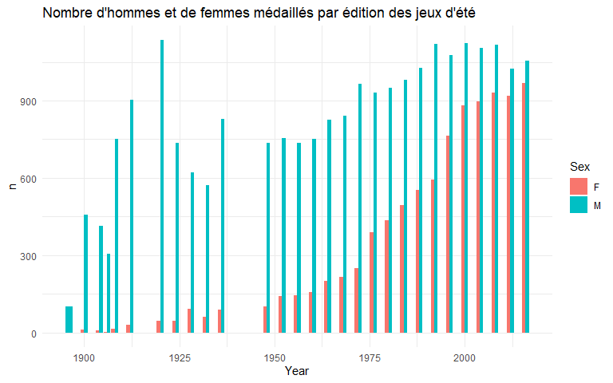

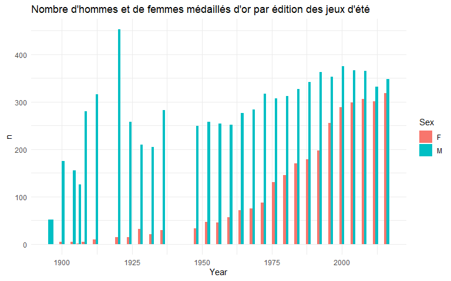

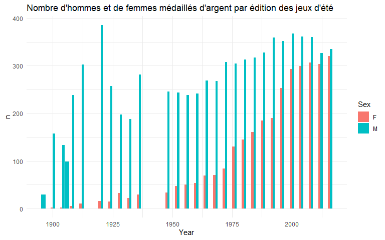

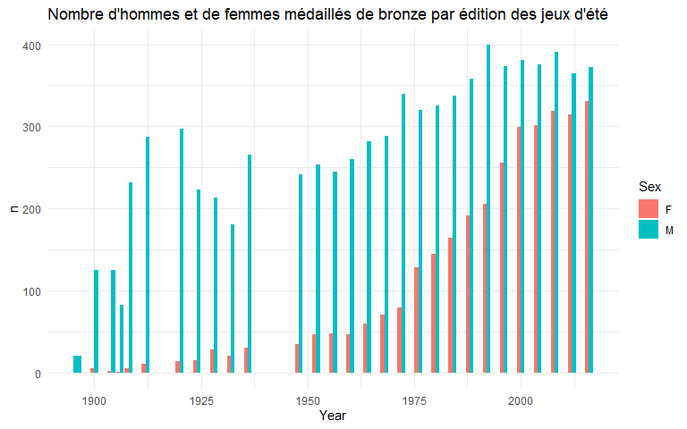

### Interprétation

La progression du nombre de médaillées féminines semble plus continue que l’augmentation d’athlètes féminines, particulièrement entre 1975 et 2000. On peut y voir une ouverture officielle des épreuves aux femmes qui a été continue tout en ayant une arrivée d’abord lente puis explosives des participants, ce qui s’explique avec le fait que dans les premières années de l’ouverture plus large des épreuves la participation des femmes était une chose moins acceptée et donc tentée. Une fois celle-ci acceptée les années suivantes ont vu la participation exploser pour ensuite se calquer petit à petit sur l’augmentation des épreuves.

Un autre point à relever est le fait qu’autant côté participation que médailles les femmes semblent atteindre un plateau depuis les années 2000 et même si la progression semble continuer elle est très limitée malgré l’écart restant avec les hommes, même si celui-ci est très nettement réduit par rapport au siècle précédent. On pourrait supposer que l’arrêt d’augmentation des médailles féminines a pu limiter l’augmentation des participations féminines puisque celles-ci poursuivent une courbe plus croissante que les médailles.

Par ailleurs il semblerait que dans les éditions les plus récentes la disparité soit plus visible pour les médailles de bronze.

## 4.Performances indivduelles

Nous cherchons à comprendre quels sont les athlètes les plus titrés de l’histoire des Jeux Olympiques, et si leur réussite est influencée par la saison (été ou hiver), la discipline sportive, ou encore la période historique à laquelle ils ont concouru.Nous partons de plusieurs hypothèses: 1. Certains sports offrent plus d’épreuves individuelles, ce qui permet aux athlètes d’accumuler un nombre plus important de médailles (ex : natation, gymnastique, ou biathlon). 2. Les Jeux d’été, proposant un plus grand nombre de disciplines, pourraient mécaniquement compter plus de champions multi-médaillés. 3. Les athlètes les plus décorés apparaissent peut-être plus fréquemment dans des périodes récentes, en raison de l’augmentation du nombre d’épreuves ou de participations aux JO sur plusieurs éditions.

Pour y répondre, nous utiliserons deux types de visualisations : - Un graphique en barres comparant les athlètes les plus titrés dans les Jeux d’été et d’hiver, avec une mise en évidence de leurs disciplines respectives. - Un nuage de points représentant la distribution dans le temps des athlètes ayant obtenu le plus de médailles, afin d’observer leur répartition historique et potentiellement dégager une tendance chronologique - De plus un graphique interactif est disponnible dans shinny

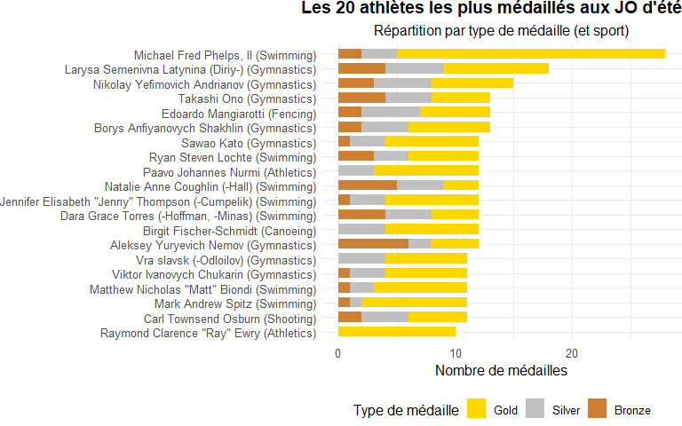

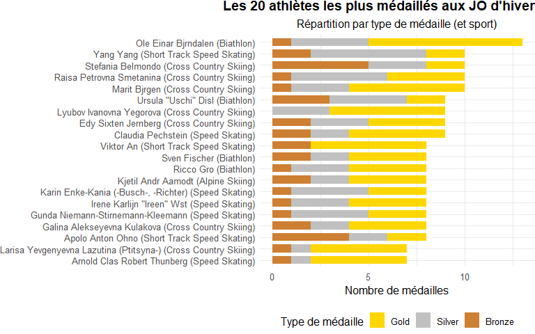

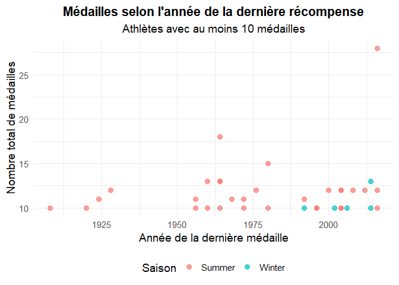

### Interpretation

Notre analyse met en lumière une forte concentration des athlètes les plus titrés dans quelques disciplines spécifiques. Aux Jeux d’été, la natation (35 épreuves à Paris 2024) et la gymnastique (18 épreuves artistiques) se distinguent : ces sports offrent de nombreuses opportunités de médailles, souvent accessibles à un même athlète lors d’une seule édition, contrairement à l’athlétisme où la spécialisation limite ce cumul. Du côté des Jeux d’hiver, ce sont le ski de fond (12 épreuves) et le patinage de vitesse (14 épreuves) qui dominent pour les mêmes raisons : formats répétitifs et participation multiple possible. On constate également que le nombre total de médailles d’été est nettement supérieur, ce qui s’explique par un programme bien plus riche (329 épreuves à Paris 2024 contre 109 en hiver).Sur le plan historique, les athlètes comptant au moins 10 médailles apparaissent majoritairement à partir des années 1950, en lien avec l’augmentation progressive du nombre d’épreuves : environ 150 épreuves en 1952, 195 en 1972, 271 en 2000, et 329 en 2024. Cette expansion du programme olympique a multiplié les occasions de médailles et favorisé l’émergence de palmarès impressionnants. Enfin, Michael Phelps reste l’athlète le plus décoré de l’histoire, avec 28 médailles, illustrant parfaitement les conditions favorables offertes par la natation pour bâtir un palmarès exceptionnel.

## 5. Evolution de la participation

Dans cette étude, nous nous intéressons à l’évolution de la participation aux Jeux Olympiques ainsi qu’aux performances des athlètes les plus titrés de leur histoire. Nous cherchons à comprendre comment le nombre d’athlètes et de pays participants a évolué au fil des éditions, en distinguant les Jeux d’été des Jeux d’hiver. En effet, la différence de participation entre ces deux saisons est significative, justifiant une analyse séparée.

Nous partons de plusieurs hypothèses. D’une part, nous supposons que le nombre de participants a globalement augmenté au fil du temps, notamment en raison de l’augmentation du nombre d’épreuves et de pays engagés. D’autre part, nous anticipons des variations liées à des événements extra-sportifs, comme des boycotts ou des conflits politiques, qui ont pu affecter certaines éditions.

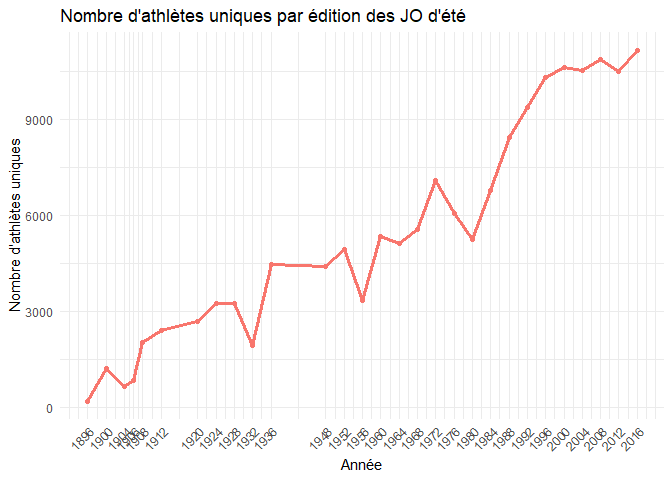

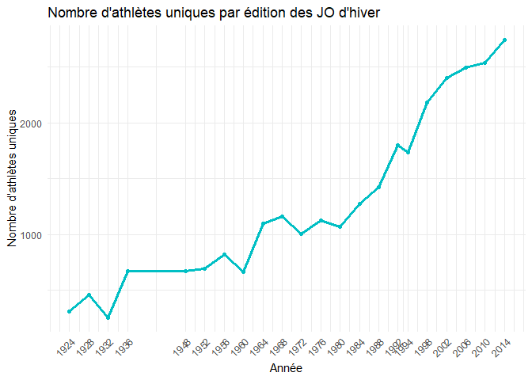

### Interpretation

L’évolution du nombre de participants aux Jeux Olympiques d’été est globalement à la hausse au fil du temps, reflétant l’expansion du mouvement olympique et la multiplication des pays et disciplines représentés. Cependant, on observe trois baisses marquées en 1932, 1956 et 1980, qui s’expliquent principalement par des contextes historiques et géopolitiques spécifiques:

- 1932 (Los Angeles) : Cette édition a connu une forte baisse de participation liée à la Grande Dépression, une crise économique mondiale majeure qui a limité les moyens financiers des pays pour envoyer leurs athlètes à l’étranger, surtout aux États-Unis, éloignés géographiquement des principaux foyers olympiques européens.
- 1956 (Melbourne) : Plusieurs boycotts politiques ont affecté ces Jeux. La crise de Suez a conduit à l’absence de plusieurs pays arabes, tandis que l’intervention soviétique en Hongrie a provoqué des boycotts de la part de nations occidentales. De plus, la République populaire de Chine a refusé de participer en réaction à la présence de Taïwan. Ces tensions politiques ont donc diminué le nombre d’athlètes présents.
- 1980 (Moscou) : Ce fut l’année du boycott massif mené par les États-Unis et plusieurs de leurs alliés, en protestation contre l’invasion soviétique de l’Afghanistan. Ce boycott a provoqué une baisse importante du nombre de participants, surtout des pays occidentaux.

On remarque une évolution similaire pour les jeux d’hivers

Une carte interactive présentant l’évolution des pays participant au JO est disponnible en shinny

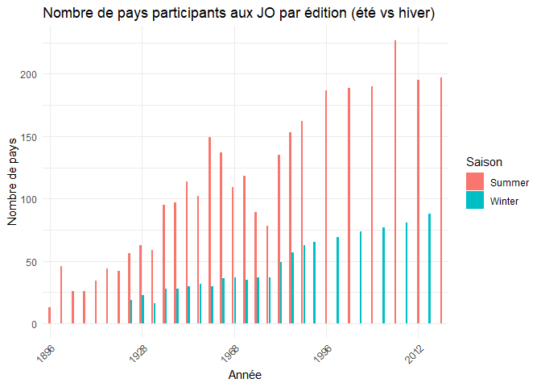

### Interpretation

Le nombre de pays participants aux Jeux Olympiques a fortement augmenté au fil du temps. Cela s’explique surtout par la décolonisation et l’indépendance de nombreux pays, ainsi que par l’ouverture du mouvement olympique à davantage de nations. On observe aussi que plus de pays participent aux Jeux d’été qu’aux Jeux d’hiver. Cela vient du fait que les sports d’hiver nécessitent des climats froids et des infrastructures spécifiques, ce qui limite la participation à certains pays seulement. Pics et creux dans la participation

## 6. Analyse morphologique

### Question 1 : Peut-on observer une tendance concernant l’évolution de la taille et le poids des athlètes ?

Dans cette section, nous nous intéressons aux caractéristiques physiques des athlètes olympiques, plus précisément à l’évolution de leur taille et de leur poids au fil du temps et selon les disciplines sportives. Nous formulons l’hypothèse que les exigences physiques propres à chaque sport influencent fortement la morphologie moyenne des athlètes. Par exemple, nous nous attendons à ce que les disciplines de force (comme l’haltérophilie) présentent des athlètes plus lourds, tandis que les disciplines artistiques ou d’endurance (comme la gymnastique ou la course) affichent des gabarits plus légers et/ou plus petits. Nous supposons également que les standards physiques ont évolué au fil des décennies, en lien avec la professionnalisation croissante du sport et les avancées en matière de préparation physique. Pour tester ces hypothèses, nous allons visualiser l’évolution de la taille moyenne et du poids moyen des athlètes par discipline et par année, à l’aide de line graphs. Ces visualisations permettront d’identifier les tendances globales ainsi que les différences entre sports. (Les versions interactives de ces graphiques sont disponibles sur shiny app afin de visualiser les tendances pour différents sports)

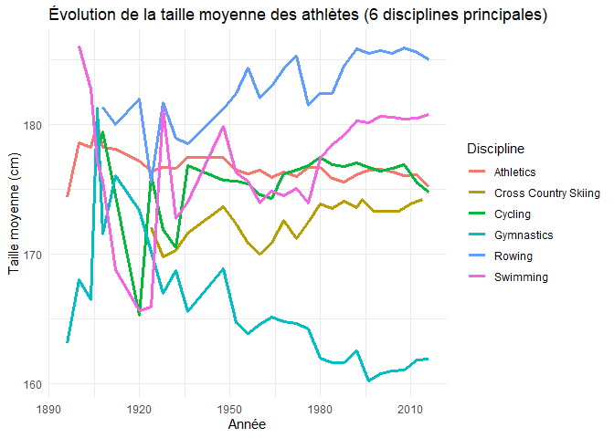

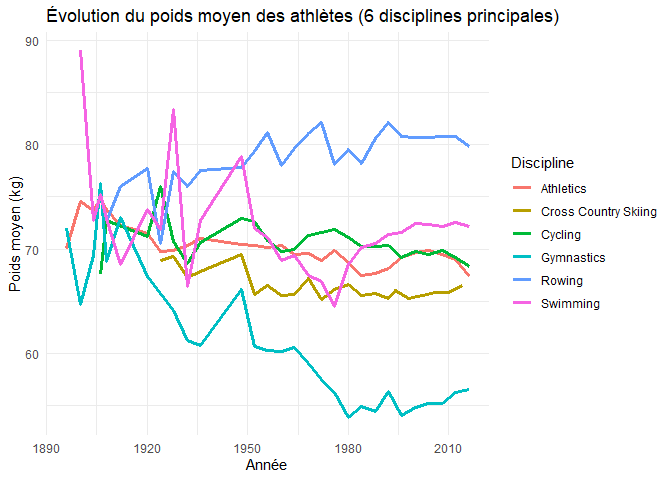

### Interprétation

Les graphiques montrent comment la taille et le poids moyens des athlètes évoluent selon les sports, en lien avec les exigences propres à chaque discipline. Par exemple, les rameurs sont généralement plus grands et plus lourds, ce qui correspond à la puissance nécessaire dans leur sport. À l’inverse, les gymnastes sont plus petits et légers, ce qui leur permet d’avoir un bon équilibre et de réaliser des mouvements techniques, avec une légère diminution de leur taille au fil du temps. Les nageurs, quant à eux deviennent de plus en plus grands, mais leur poids reste modéré pour faciliter la glisse dans l’eau. Les cyclistes et les skieurs de fond ont des tailles et des poids moyens plutôt stables, car ils ont besoin d’un équilibre entre endurance et puissance. Enfin, les athlètes en général montrent des valeurs assez constantes, probablement lié à la diversité des épreuves dans l’athlétisme nécessitant d’avoir un physique “hybride”. En revanche on ne peut pas distinguer de tendance générale sur l’évolution du poids et de la taille des athlètes de manière générale au fil du temps.

Cependant cette analyse démographique soulève une question intéressante concernant la sélectivité physique dans certaines disciplines sportives. En effet, les méthodes de préparation physique étant de plus en plus poussées il est possible qu’un “physique type” soit désormais nécessaire pour atteindre le top niveau.

### Question 2 : Certaines disciplines deviennent-elles de plus en plus sélectives physiquement au point d’exclure certains profils morphologiques ?

Pour explorer cette question, nous pouvons formuler l’hypothèse suivante : si effectivement certaines disciplines deviennent de plus en plus sélectives physiquement, cela pourrait se traduire par une diminution de la variance de la taille et du poids des athlètes au fil du temps. Une variance plus faible indiquerait une uniformisation des profils physiques, suggérant une sélectivité accrue.

Pour tester cette hypothèse, nous allons calculer la variance de la taille et du poids des athlètes pour chaque discipline et chaque année, puis visualiser ces variances à l’aide de line graphs.

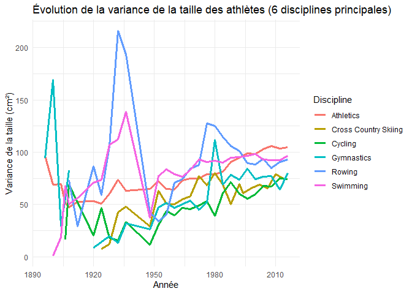

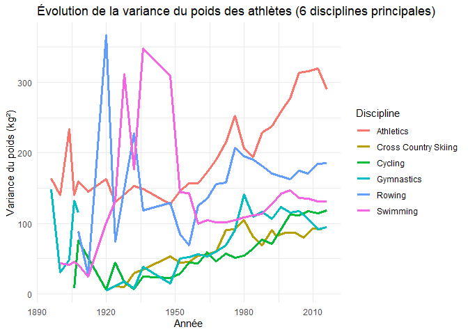

### Interprétation

Malgré une tendance générale à la hausse de la variance depuis 1950 pour ces six disciplines sportives, nous pouvons observer que la variance de la taille reste relativement faible, indiquant que les athlètes ont, en général, des tailles assez similaires au sein de chaque discipline. En revanche, pour le poids, la variance est non seulement plus élevée que pour la taille, mais certaines disciplines se distinguent par des variances encore plus prononcées, révélant une hétérogénéité plus marquée dans le poids des athlètes selon les sports.

Ces différences peuvent s’expliquer par la diversité des rôles au sein des sports et par l’optimisation des caractéristiques physiques pour répondre aux exigences spécifiques de chaque discipline. Par exemple, en natation, bien que les nageurs aient des tailles relativement similaires pour minimiser la résistance dans l’eau, les variations de poids peuvent être plus prononcées. En effet, les nageurs de sprint peuvent avoir une composition corporelle plus musculaire pour des départs explosifs, tandis que les nageurs de fond peuvent avoir une composition plus légère pour favoriser l’endurance.

Ainsi, bien que certaines disciplines montrent une uniformisation de la taille, la diversité des poids suggère que les sports ne sont pas nécessairement devenus plus sélectifs sur les morphologies, mais plutôt plus adaptatifs aux différentes spécialisations.

## 7. Analyse des villes hôtes

Cette section examine la répartition géographique des villes ayant accueilli les Jeux Olympiques, afin d’identifier d’éventuels déséquilibres régionaux. Nous partons de l’hypothèse que les pays du Nord (Europe, Amérique du Nord, Asie de l’Est) ont été surreprésentés, tandis que l’Afrique, l’Amérique latine et l’Asie du Sud ont été peu sollicitées. Pour tester cette hypothèse, nous cartographierons les villes hôtes par type de Jeux (été/hiver) et nombre de fois qu’elles ont été hôte afin de repérer d’éventuelles concentrations géographiques.

### Question 1 : Y a-t-il une tendance géographique dans le choix des villes hôtes au fil des années ?

Pour répondre à cette question, nous allons produire une carte du monde représentant les villes hôtes des Jeux Olympiques, avec un code couleur indiquant le type de Jeux (été/hiver) et la taille des points indiquant le nombre de fois qu’une ville a été hôte. Cette visualisation permettra d’identifier s’il existe des zones privilégiées dans l’attribution des Jeux Olympiques et si cette tendance évolue vers plus de diversité géographique au cours des décennies.

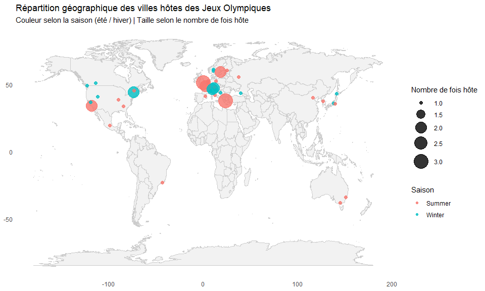

### Interprétation

La carte met en évidence une concentration marquée des Jeux Olympiques dans les pays du Nord, notamment en Europe de l’Ouest, en Amérique du Nord et au Japon. Cette répartition n’est pas due au hasard : elle reflète la capacité logistique, économique et politique de certains pays à organiser un événement d’une telle ampleur. Accueillir les Jeux suppose des infrastructures sportives modernes, des réseaux de transport efficaces, une stabilité politique, et un budget conséquent. Historiquement, seuls les pays industrialisés répondaient à ces exigences.

Les villes comme Paris, Londres ou Los Angeles apparaissent à plusieurs reprises, ce qui montre une tendance à réattribuer les Jeux à des villes déjà expérimentées. À l’inverse, l’Afrique est totalement absente, et l’Amérique du Sud n’est représentée que par Rio en 2016. Cela illustre un déséquilibre persistant, où les critères d’attribution favorisent les pays les plus riches et les mieux équipés, au détriment d’une véritable diversité géographique. Par ailleurs, cet aspect n’est pas sur le point de changer puisque les derniers jeux se sont déroulés à Paris et les prochains se dérouleront à Los Angeles.

# Conclusion

Ce projet d’analyse des **Jeux Olympiques (1896-2020)**, mené dans le cadre de l’UE **IF36 – Visualiser des données**, nous a permis d’explorer un siècle de compétitions à travers la **data visualisation avec R**. Grâce à un jeu de données riche en informations démographiques, sportives et géopolitiques, nous avons pu identifier des **tendances majeures** et mettre en lumière des **phénomènes complexes** comme l’effet pays hôte ou les disparités de genre.

## Apports de l’analyse

### Disparités et évolutions

L’analyse des **disparités de genre** et de l’**évolution morphologique** des athlètes a mis en évidence une **augmentation progressive de la participation féminine**, ainsi qu’une adaptation des caractéristiques physiques (taille, poids) aux exigences spécifiques des disciplines. Ces tendances soulignent l’évolution constante des standards de performance.

### Contexte historique et tendances globales

Nos visualisations ont aussi permis de relier certaines **fluctuations de participation et de médailles** à des événements historiques majeurs tels que les **guerres mondiales** ou les **boycotts**, révélant la forte **dimension politique** des Jeux.

## Difficultés rencontrées

### Problèmes de données

Les jeux de données, bien que complets, présentaient des **valeurs manquantes** (notamment sur l’âge ou la nationalité des athlètes), nécessitant un **nettoyage rigoureux**. La fusion des trois datasets issus de Kaggle a également représenté un défi technique important.

### Comparabilité temporelle

Comparer les performances sur plus de 100 ans est délicat, en raison de nombreux **changements de règles**, **ajouts de disciplines** ou **conflits géopolitiques**. Ces facteurs introduisent des **biais d’interprétation**, qu’il a fallu prendre en compte dans l’analyse.

### Complexité de l’effet pays hôte

Il a été nécessaire de **distinguer l’effet direct** de l’accueil des Jeux (logistique, motivation nationale) de la **puissance sportive structurelle** déjà en place dans le pays hôte.

## Perspectives

- **Analyse socio-économique** : intégrer des données comme le **PIB**, les **investissements publics dans le sport** ou les **retombées économiques** de l’accueil des Jeux permettrait de mieux comprendre les dynamiques de performance.
- **Facteurs environnementaux** : étudier l’impact du **climat**, de **l’altitude**, ou d’autres facteurs géographiques sur les performances.
- **Étude qualitative post-JO** : comparer les **politiques sportives post-olympiques** pour comprendre pourquoi certains pays transforment mieux que d’autres leur expérience en **succès durables**.
- **Modélisation prédictive** : développer des **modèles de prédiction du nombre de médailles**, par pays ou par discipline.
- **Analyse des Jeux d’hiver** : reproduire ce travail sur les Jeux Olympiques d’hiver pour mettre en évidence des **spécificités saisonnières**.

## Mots de la fin

**Cheikh** :  
> « Ce projet, étant l’un de mes premiers en visualisation de données, m’a permis de solidifier ma maîtrise de la manipulation de données complexes avec dplyr et de la visualisation avancée avec ggplot2. J’ai vraiment appris à faire parler les données. »

**Guillaume** :  
> « Ce projet m’a permis de découvrir concrètement l’analyse de données et de me familiariser avec le langage R. J’ai apprécié le transfert d’un graphique sur Tableau. »

**Élia** :  
> « J’ai pu approfondir mes compétences en R et apprendre à créer des visualisations claires et pertinentes. J’aurais aimé documenter davantage les résultats avec des données historiques. »

**Hippolyte** :  
> « Ce projet m’a permis d’améliorer mes compétences en R, notamment avec Shiny. Le sujet des JO était passionnant et j’aurais aimé aller plus loin sur certains sports spécifiques. »

# Annexe – Répartition du travail

Ce projet a été réalisé en collaboration, avec une répartition des tâches claire :

### Cheikh :

- Analyse de l’effet pays hôte (avant/pendant/après)
- Développement des hypothèses
- Visualisations des évolutions de médailles

### Guillaume :

- Analyse âge vs performance
- Étude morphologique (taille, poids)
- Graphiques interactifs dans Shiny (taille, poids, âge moyen)

### Élia :

- Analyse des disparités de genre

### Hippolyte :

- Analyse des performances individuelles
- Étude de la participation historique
- Visualisations Shiny (carte interactive, bar chart médailles)

Chaque membre a également contribué à la **collecte, au nettoyage**, ainsi qu’à la **relecture croisée des analyses**.